# Tabelas Resultado Artigo 3

Tony Araujo

2022-07-15

# Principais Resultados

A variável dependente é a votação na Emenda Aglutinativa 22, que propunha que o financiamento direto de PF e PJ aos candidatos fosse permitido. Foram 251 Votos Sim ( A favor), 203 Votos Não ( Contra), 4 abstenções. Apesar de ter 54% de Deputados favoráveis a Emenda foi rejeitada.

## Tabela comparando LOGIT x OLS

|  | Logit | Logit Robusto | OLS | OLS Robusto |
| --- | --- | --- | --- | --- |
| Ideologia | 3.929*** | 3.929*** | 0.362*** | 0.362*** |
|  | (0.688) | (0.708) | (0.060) | (0.062) |
| Orientação Contra | -2.782*** | -2.782*** | -0.491*** | -0.491*** |
|  | (0.399) | (0.392) | (0.049) | (0.058) |
| Rec.PJ | 0.023* | 0.023* | 0.004** | 0.004** |
|  | (0.009) | (0.010) | (0.001) | (0.001) |
| Rec.PF | 0.015 | 0.015 | 0.003* | 0.003* |
|  | (0.012) | (0.011) | (0.001) | (0.001) |
| Rec.Próprios | 0.007 | 0.007 | 0.001 | 0.001 |
|  | (0.011) | (0.012) | (0.001) | (0.002) |
| Rec.Partido | 0.022* | 0.022* | 0.003** | 0.003** |
|  | (0.009) | (0.009) | (0.001) | (0.001) |
| NE | 1.258* | 1.258* | 0.125 | 0.125 |
|  | (0.536) | (0.525) | (0.068) | (0.075) |
| N | 1.341* | 1.341* | 0.135 | 0.135 |
|  | (0.604) | (0.606) | (0.076) | (0.084) |
| SE | 1.282* | 1.282* | 0.132* | 0.132 |
|  | (0.523) | (0.534) | (0.066) | (0.074) |
| S | 0.360 | 0.360 | 0.038 | 0.038 |
|  | (0.569) | (0.535) | (0.074) | (0.081) |
| Oposição | -0.337 | -0.337 | -0.057 | -0.057 |
|  | (0.318) | (0.339) | (0.041) | (0.047) |
| Político | -0.298 | -0.298 | -0.024 | -0.024 |
|  | (0.298) | (0.302) | (0.034) | (0.033) |
| Superior | -0.362 | -0.362 | -0.023 | -0.023 |
|  | (0.344) | (0.356) | (0.041) | (0.043) |
| Casado | 0.241 | 0.241 | 0.032 | 0.032 |
|  | (0.325) | (0.349) | (0.038) | (0.039) |
| Num.Obs. | 454 | 454 | 454 | 454 |
| R2 |  |  | 0.526 |  |
| R2 Adj. |  |  | 0.510 |  |
| AIC | 354.5 |  | 347.4 | 1193.4 |
| BIC | 416.3 |  | 413.3 | 3001.2 |
| Log.Lik. | -162.270 |  | -157.692 |  |
| F | 7.473 |  | 34.739 |  |
| RMSE | 0.33 |  | 0.34 |  |

* p < 0.05, ** p < 0.01, *** p < 0.001

## Tabela com Várias especificações do Modelo Logit Não Robusto

O intuito é ver se ao acrescentar uma variável os parâmetros mudam muito, seria um indicativo de multicolinearidade.

|  | Model 1 | Model 2 | Model 3 | Model 4 | Model 5 |
| --- | --- | --- | --- | --- | --- |
| Ideologia | 3.578*** | 3.751*** | 3.827*** | 3.950*** | 3.929*** |
|  | (0.630) | (0.659) | (0.667) | (0.687) | (0.688) |
| Orientação Contra | -2.830*** | -2.788*** | -2.791*** | -2.770*** | -2.782*** |
|  | (0.396) | (0.398) | (0.398) | (0.399) | (0.399) |
| Rec.PJ | 0.024** | 0.023* | 0.022* | 0.024** | 0.023* |
|  | (0.009) | (0.009) | (0.009) | (0.009) | (0.009) |
| Rec.PF | 0.016 | 0.016 | 0.015 | 0.015 | 0.015 |
|  | (0.012) | (0.012) | (0.012) | (0.012) | (0.012) |
| Rec.Próprios | 0.007 | 0.007 | 0.006 | 0.006 | 0.007 |
|  | (0.011) | (0.011) | (0.011) | (0.011) | (0.011) |
| Rec.Partido | 0.022* | 0.021* | 0.021* | 0.022* | 0.022* |
|  | (0.009) | (0.009) | (0.009) | (0.009) | (0.009) |
| NE | 1.287* | 1.324* | 1.314* | 1.258* | 1.258* |
|  | (0.529) | (0.529) | (0.532) | (0.535) | (0.536) |
| N | 1.405* | 1.391* | 1.406* | 1.331* | 1.341* |
|  | (0.596) | (0.595) | (0.597) | (0.602) | (0.604) |
| SE | 1.302* | 1.304* | 1.310* | 1.278* | 1.282* |
|  | (0.521) | (0.519) | (0.521) | (0.523) | (0.523) |
| S | 0.427 | 0.428 | 0.440 | 0.384 | 0.360 |
|  | (0.559) | (0.559) | (0.562) | (0.567) | (0.569) |
| Oposição |  | -0.272 | -0.314 | -0.328 | -0.337 |
|  |  | (0.313) | (0.317) | (0.317) | (0.318) |
| Político |  |  | -0.285 | -0.286 | -0.298 |
|  |  |  | (0.298) | (0.298) | (0.298) |
| Superior |  |  |  | -0.370 | -0.362 |
|  |  |  |  | (0.344) | (0.344) |
| Casado |  |  |  |  | 0.241 |
|  |  |  |  |  | (0.325) |
| Num.Obs. | 454 | 454 | 454 | 454 | 454 |
| AIC | 349.9 | 351.2 | 352.3 | 353.1 | 354.5 |
| BIC | 395.2 | 400.6 | 405.8 | 410.7 | 416.3 |
| Log.Lik. | -163.972 | -163.596 | -163.133 | -162.543 | -162.270 |
| F | 10.381 | 9.646 | 8.830 | 8.051 | 7.473 |
| RMSE | 0.34 | 0.34 | 0.34 | 0.34 | 0.33 |

* p < 0.05, ** p < 0.01, *** p < 0.001

## Gráfico com parâmetros estimados

As cores indicam sinal positivo ou negativo. A significância é indicada pela bola preenchida ( 5%) e as linhas indicam o intervalo de Confiança de 95%.

TRUE

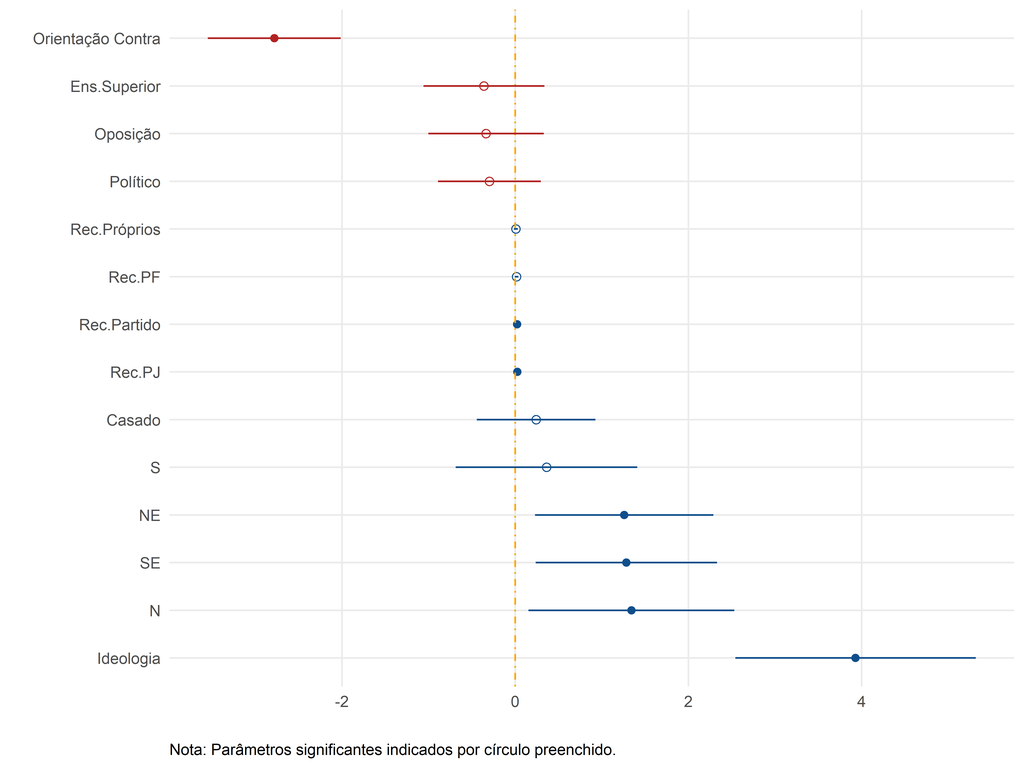

Os resultados indicam que ser mais financiado por PJ aumenta a chance de votar a favor da EMA 22, assim como ser mais financiado pelo próprio Partido. Os deputados mais a direita, ideologicamente, votaram a favor. Para os deputados cujo partido foi explicitamente contra a EMA, orientando a votar não, a chance de Votar Não foi maior. Existe também um componente regional nessa “historia”. Quem era do CO tinha menor probabilidade, em relação às demais regiões, de votar a favor. Retirei, além do patrimonio, algumas carcateristicas pessoais dos candidadtos, como Sexo (todos eram homens, praticamente). A variável Político tem valor igual a 1 quando a ocupação do Deputado, no momento da candidatura é Deputado, Vereador ou Senador.

Sintetizando, aquela hipótese da barreira à entrada não foi confirmada. Talvez se olharmos a nível de partido, saber por que o partido orientou a votar contra, tenhamos algo nesse sentido.

Também vou calcular os efeitos marginais e incluir algumas métricas de previsão.